# *ROLLING DOWN A CROWDED VALLEY OF OPTIMIZERS: DEVELOPMENTS FROM SGD*

Introduction

- Gradient Descent
- Stochastic Gradient Descent(SGD)
- Mini-batch Gradient Descent
- SGD with Momentum
- Nestrov Accelerate Gradient (NAG)
- AdaGrad
- RMS-prop
- ADAM
- Visualizing various Optimizers
- AdaMax
- Nadam
- AMSGrad
- AdaBelief

Which optimizer to trust?

Conclusion

### Introduction

Optimizers are parameters used in machine learning algorithms to update the weights for the loss function in the backpropagation of the neural network.

Let's look at 2 essential terms used in machine learning and deep learning algorithms using optimizers as their parameters:

**Epochs** - an event or a time marked by an event that begins a new period or development. (dictionary definition). Epoch indicates the number of passes of the entire training dataset a machine learning algorithm has completed. Datasets are broken and grouped into batches (when the amount of data is very large). So, each epoch indicates the pass for each batch-size of the dataset.

**Iterations** - indicates the number of times the algorithm's parameters are updated.

Training of a neural network will require many iterations. At each iteration the parameters and the learning rate is updated and a new iteration is performed with new values for all the epochs.

A typical example of a single iteration of training of a neural network would include the following steps:

1. processing the training dataset batch-size
2. calculating the cost function
3. backpropagation and adjustment of all weighting factors

In a neural network, first we perform forward propagation for the output and based on that we create a loss or error (or cost) function to calculate the error function.

$$\begin{align} Loss/Error = \frac{1}{2}(y-\hat{y})^{2} → MSE \end{align}$$

When we compute the loss function the aim is to reduce the error which is done using optimizers.

Optimizers update the weights for the function in backpropagation of the neural network.

## **1. Gradient Descent *$\color{green}{(Cauchy, 1857)}$*:**

Gradient Descent (GD) is a method to minimize the cost function J() in each step. It iteratively updates the weights and bias trying to reach the global minimum in the cost function. The new weights are calculated as

$$\begin{align} W_t = W_{t-1} - \eta . \frac{\partial \mathcal{J}(\mathbf{L})}{\partial \mathbf{W}_{t-1}} \end{align}$$

Gradient descent takes the complete dataset and then updates the weight for the entire dataset. The process would be very slow for a large number of records (say 10 million records).

This is because the weights and bias updation will take time and *hence the convergence will happen slowly.* Although it provides stable convergence and a stable error, it is very slow for big datasets. This makes Gradient descent more resource intensive using very high RAM and computationally expensive.

[figure not shown]

*Batch gradient descent is sensitive to saddle points, which can lead to premature convergence*

## **2. Stochastic Gradient Descent (SGD) *$\color{royalblue}{(Robinds, and Monro, 1951)}$*:**

To overcome the problem of Gradient descent for the entire dataset, SGD takes a single record at a time, performs the forward propagation and the backpropagation for each record. This will lead to performing 1 epoch at a time. So, the number of iterations will be (1 epoch X Number of records) as compared to Gradient Descent where there was only a single iteration for the entire number of records.

The process will again be very slow as we are taking 1 record at a time. So for each epoch, the SGD optimizer will perform backpropagation calculating the error or cost function and update the weight each time. Again the weight updation will take time for each epoch and hence again the convergence will happen slowly.

Stochastic Gradient Descent is less resource intensive using less RAM and less computationally expensive.

For such a huge number of records the loss function would be:

$$\begin{align} SGD_{Loss} = \frac{1}{2} {\sum}_{i=1}^{N}(y_i-\hat{y_i})^{2} \end{align}$$

The error or loss surface can be visualised as a set of contours and can be represented as contour plots as shown below.

[figure not shown]

## **3. Mini-batch Gradient Descent:**

To overcome the problems in SGD, the researchers came up with an approach to take a mini-batch size for every epoch. So the entire dataset is broken into batches, taken as mini-batch size for the epochs. For 1 million records say for 1000 batch-size, the number of iterations will be (Number of records/batch-size) 1000 iterations.

This allows in moving quickly to the global minimum in the cost function and updating the weights and biases multiple times per epoch now. Most common mini-batch sizes used are 16, 32, 64, 128, 256, 512 and 1024.

[figure not shown]

In comparison to SGD in mini-batch GD the convergence will not be as smooth as SGD. This is because every batch-size in mini-batch GD will create a noise which is added upon to the previous batch-size.

Let's just try to draw in a representative graph what we discussed above. We will be enhancing this representation for further discussions. It can be noted that the representation just is for the purpose of understanding, it may not be accurately correct.

[figure not shown]

Also, compared to a batch gradient descent which is very slow mini-batch performs well.

However, a mini-batch gradient descent may help in escaping a shallow local minima, but it often fails when dealing with a situation of deep local minima.

[figure not shown]

*Even a stochastic error surface won’t save us from a deep local minimum.* *(Source: Buduma, Nikhil, Fundamentals of Deep Learning)*

## **4. SGD with Momentum *$\color{violet}{(Polyak, 1964)}$*:**

To overcome the noise generated in the mini-batch gradient descent, researchers came up with a new technique to add momentum to the batch-size which would smoothen the noise. Momentum is a method to accelerate SGD in a specific direction dampening the oscillations or noise.

In order to smoothen the convergence, weights are averaged and exponential weighted average is calculated.

It is does by adding a fraction $\gamma$ of the update vector of past time step to the current update vector:

$$\begin{align} v_t = \gamma v_{t-1} - \eta . \frac{\partial \mathcal{J}(\mathbf{L})}{\partial \mathbf{W}_{t-1}} \\ \\ W_t = W_{t-1} - v_t \\ \end{align}$$

Now, let us find V at different time intervals for corresponding displacement using below table to get an inception on the equation we will be using for momentum:

$$\begin{align} &\ a_1 &&\ a_2 &&\ a_3 &&\ a_4 \\ &\ t_1 &&\ t_2 &&\ t_3 &&\ t_4 \\ \end{align}$$$$\begin{align} v_{t_1} = a_1 \\ v_{t_2} = \beta v_{t_1} + (1-\beta)a_2 \\ v_{t_3} = \beta v_{t_2} + (1-\beta)a_3 \\ v_{t_3} = \beta.(\beta a_1 + (1-\beta)a_2 ) + (1-\beta)a_3 \\ v_{t_3} = \beta^{2}a_1 + (\beta-\beta^{2})a_2 + (1-\beta)a_3 \\ \end{align}$$

and so on...

Applying the same approach to find the first momentum equation for weights $V_{dW_t}$ and biases $V_{db_t}$

$$\begin{align} V_{dW_t} = \beta V_{dW_t-1} + (1-\beta) \frac{\partial \mathcal{J}(\mathbf{L})}{\partial \mathbf{W}_{t-1}} \\ W_t = W_{t-1} + V_{dW_t} \\ \\ V_{db_t} = \beta V_{db_t-1} + (1-\beta) \frac{\partial \mathcal{J}(\mathbf{L})}{\partial \mathbf{b}_{t-1}} \\ b_t = b_{t-1} + V_{db_t} \end{align}$$

The momentum term $\beta$ is usually set in the range 0.90 - 0.95 to give more weightage to the previous values.

## **5. NAG (Nesterov Accelerated Gradient)*$\color{orange}{(Nesterov, 1983)}$*:**

After momentum was gained on SGD (Polyak, 1964), a similar update was implemented using Nesterov Accelerated Gradient (Sutskever et al., 2013). This update utilises m, the exponential moving average of what we would call projected gradients.

**Note:** *The analogy, a ball rolling down a valley, would blindly follow the slope, is highly undesirable.* \ *Instead let us consider a smarter ball which has a presumption of where it is heading such that it knows to slow down before the hill slopes up again.*

Nesterov accelerated gradient (NAG) is a way to provide the momentum term this kind of steadiness. The Nesterov momentum is based on the fact that if we know the velocity and the direction of a moving object, we can predict its future vector location at time T.

[figure not shown]

A picture of Nesterov method (Source: [G. Hinton's lecture 6c](http://www.cs.toronto.edu/~tijmen/csc321/slides/lecture_slides_lec6.pdf))

- **$\color{darkorange}{First}$** make a big jump in the direction of the previous accumulated gradient.
- **$\color{royalblue}{Then}$** measure the gradient where you end up and make a correction.

First calculate the current gradient (the blue tiny vector) using Momentum and then make a large jump in the direction of the upgraded accumulated gradient (the blue large vector). NAG initially makes a large jump in the direction of the preceding accumulated gradient (the brown vector), measures the corresponding gradient and then takes a correction (the red vector), which results in the complete NAG update (the green vector).

*Afterall, it’s better to correct your mistakes $\color{royalblue}{after}$ you have made them!*

We know that we would use the momentum term $\gamma v_{t-1}$ to move the parameters.

Calculating $L-\gamma v_{t-1}$ gives us an approximation of the next position of the parameters (the gradient is missing for the full update), a rough idea where our parameters are going to be.

We can now effectively look ahead by calculating the gradient not w.r.t. to our current parameters $L$ but w.r.t. the approximate future position of our parameters:

$$\begin{align} v_t = \gamma. v_{t-1} + \eta. \frac{\partial \mathcal{J}(\mathbf{L-\gamma v_{t-1}})}{\partial \mathbf{W}_{t-1}} \\ \\ W_t = W_{t-1} - v_t \\ \end{align}$$

The value of momentum term is set to 0.9

## **6. Adagrad (Adaptive Gradient Descent) *$\color{darkorange}{(Duchi, Hazan, and Singer, 2011)}$*:**

In all of the above optimizers, the learning rate $\eta$ was kept fixed and the focus was to change the rate of descent and smoothen it. However, the researchers came up with another technique to change the learning rate $\eta$.

Here, as the training on the algorithm is going on, the learning rate $\eta$ is dynamically changed. The learning rate $\eta$ starts with a defined value say 0.1 and the value gradually decreases when we descend towards the convergence point.

If we try to represent Mini-batch GD, SGD with momentum and Adagrad together it would look like this as drawn in the image below.

[figure not shown]

From Gradient Descent we have, $$\begin{align} W_t = W_{t-1} - \eta. \frac{\partial \mathcal{J}(\mathbf{L})}{\partial \mathbf{W}_{t-1}} \\ \end{align}$$

However, we need to define $\eta_t'$ for changing learning rate with the change in step $$\begin{align} W_t = W_{t-1} - \eta_t'. \frac{\partial \mathcal{J}(\mathbf{L})}{\partial \mathbf{W}_{t-1}} \\ \end{align}$$

if $$\begin{align} g_{t-1} = \frac{\partial \mathcal{J}(\mathbf{L})}{\partial \mathbf{W}_{t-1}} \\ \end{align}$$ where,

$$\begin{align} \eta_t' = \frac{\eta}{\sqrt{\alpha_t+\epsilon}} \\ \end{align}$$$$\begin{align} \alpha_t = \sum_{i=1}^{t} ( g_{t-1} )^2 \\ \end{align}$$

Initial learning rate $\eta$ - 0.01 and epsilon ($\epsilon$) is a small positive number to prevent division by zero error. In the above equation for each new weight at time t, $\alpha_t$ will go on to increase as the summation of $( \frac{\partial \mathcal{J}(\mathbf{L})}{\partial \mathbf{W}_{t-1}} )^2$ will produce a large value at every iteration.

Hence, new learning rate $\eta_t'$ will go on to decrease in each iteration as we descent down to the convergence point. This is how **Adagrad** adapts the learning rate to the parameters, it performs larger updates (i.e. high learning rates) for parameters associated with infrequent features, and smaller updates (i.e. low learning rates) for parameters associated with frequently occurring features.

## **7. RMS-prop *$\color{green}{(Tieleman, and Hinton, 2012)}$*:**

Adadelta extends Adagrad in reducing the aggressively decreasing learning rate. Here, the sum of gradients is recursively defined as a decaying average of all past squared gradients.

$$\begin{align} \eta_t' = \frac{\eta}{\sqrt{S_{dW}+\epsilon}} \\ \\ g_{t} = \frac{\partial \mathcal{J}(\mathbf{L})}{\partial \mathbf{W}_{t}} \\ \\ S_{dW_t} = \beta S_{dW_{t-1}} + (1-\beta).( g_t)^2 \end{align}$$

For a standard $\beta$= 0.95 as mentioned above in momentum.

$$\begin{align} S_{dW_t} = (0.95) S_{dW_{t-1}} + (0.05).( g_t)^2 \\ \end{align}$$

This restricts the squared values of accumulated past gradients by multiplying it with a small number thus preventing $S_{dW_t}$ to have very large values as $\alpha_t$ in Adagrad.

#### **Implementation details:**

1. On iteration t in minibatch
2. Compute $\frac{\partial \mathcal{J}(\mathbf{L})}{\partial \mathbf{W}_{t}}$ for weights and $\frac{\partial \mathcal{J}(\mathbf{L})}{\partial \mathbf{b}_{t}}$ for biases
3. Exponential decay of past squared gradients $$\begin{align} S_{dW_t} = \beta S_{dW_{t-1}} + (1-\beta).(\frac{\partial \mathcal{J}(\mathbf{L})}{\partial \mathbf{W}_{t}})^2 \\ \\ S_{db_t} = \beta S_{db_{t-1}} + (1-\beta).( \frac{\partial \mathcal{J}(\mathbf{L})}{\partial \mathbf{b}_{t}})^2 \\ \end{align}$$
4. Weights updation and bias updations will be $$\begin{align} W_t = W_{t-1} - \eta_t'. \frac{\partial \mathcal{J}(\mathbf{L})}{\partial \mathbf{W}_{t-1}} \\ b_t = b_{t-1} - \eta_t'. \frac{\partial \mathcal{J}(\mathbf{L})}{\partial \mathbf{b}_{t-1}} \\ \eta_t' = \frac{\eta}{\sqrt{S_{dW}+\epsilon}} \\ \end{align}$$

On comparing RMS-prop to Momentum as shown below from Andrew Ng's lectures, we can see that RMSprop is faster.

[figure not shown]

**$\color{royalblue}{Momentum (blue)}$ and $\color{green}{RMSprop (green)}$ convergence.** (Source: Ng, Andrew [Youtube video](https://www.youtube.com/watch?v=_e-LFe_igno&t=256s&ab_channel=DeepLearningAI))

## **8. ADAM (Adaptive Moment Estimation)*$\color{red}{(Kingma, and Ba, 2015)}$*:**

Adam computes adaptive learning rates for each parameter, keeping an exponential decay average of past gradients, similar to momentum.

$\star$ With momentum, we get a better smoothening - accounting for exponentially decaying average of the previous gradients and;

$\star$ With RMS-prop we are able to change the learning rate in an efficient manner - contributing to the exponentially decaying average of the previous squared gradients.

#### **Algorithm implementation:**

1. Set initially, $V_{dW} = V_{db} = S_{dW} = S_{db} = 0$
1. On iteration t, calculate the gradients for loss function with respect to weights and bias using the current mini-batch i.e., $\frac{\partial \mathcal{J}(\mathbf{L})}{\partial \mathbf{W}_{t-1}}$ and $\frac{\partial \mathcal{J}(\mathbf{L})}{\partial \mathbf{b}_{t-1}}$
1. Calculate: $V_{dW}$ and $V_{db}$ with respect to **Momentum**~

$$\begin{align} V_{dW_{t}} = \beta_1.V_{dW_{t-1}} + (1-\beta_1).\frac{\partial \mathcal{J}(\mathbf{L})}{\partial \mathbf{W}_{t-1}} \\ V_{db_{t}} = \beta_1.V_{db_{t-1}} + (1-\beta_1).\frac{\partial \mathcal{J}(\mathbf{L})}{\partial \mathbf{b}_{t-1}} \\ \end{align}$$

1. Calculate: $S_{dW}$ and $S_{db}$ with respect to **RMSprop**~

$$\begin{align} S_{dW_{t}} = \beta_2.S_{dW_{t-1}} + (1-\beta_2).(\frac{\partial \mathcal{J}(\mathbf{L})}{\partial \mathbf{W}_{t-1}})^2 \\ S_{db_{t}} = \beta_2.S_{db_{t-1}} + (1-\beta_2).(\frac{\partial \mathcal{J}(\mathbf{L})}{\partial \mathbf{b}_{t-1}})^2 \\ \end{align}$$

1. Weights updation and bias updations will be ~

$$\begin{align} W_t = W_{t-1} - \frac{\eta}{\sqrt{S_{dW}}+\epsilon}. V_{dW_{t}} \\ b_t = b_{t-1} - \frac{\eta}{\sqrt{S_{db}}+\epsilon}. V_{db_{t}} \\ \end{align}$$

1. Apply bias corrections to weight and bias updations ~ (mentioned below in Bias corrections).

$V_{dW_{t}}$ and $S_{dW_{t}}$ are estimates of the first moment (the mean) and the second moment (the uncentered variance) of the gradients respectively. It is represented as $m_t$ and $v_t$ in the papers for momentum and variance, hence the name of the method.

$V_{dW_{t}}$ and $S_{dW_{t}}$ are initialized as vectors of zeros, (Kingma and Ba) the authors of Adam observed that they are biased towards zero, especially during the initial time steps, and especially when the decay rates are small (i.e. $\beta_1$ and $\beta_2$ are close to 1).

#### **Bias corrections:**

In order to counteract the biases, compute the bias-corrected first and second moment estimates:

$$\begin{align} V_{dW_{t}}^{Correction} = \hat{V_{dW_{t}}} = \frac{V_{dW_{t}}}{(1-\beta_1^t)} \\ V_{db_{t}}^{Correction} = \hat{V_{db_{t}}} = \frac{V_{db_{t}}}{(1-\beta_1^t)} \\ \\ S_{dW_{t}}^{Correction} = \hat{S_{dW_{t}}} = \frac{V_{dS_{t}}}{(1-\beta_2^t)} \\ S_{db_{t}}^{Correction} = \hat{S_{db_{t}}} = \frac{S_{db_{t}}}{(1-\beta_2^t)} \\ \end{align}$$

The authors Kingma and Ba used these corrections to update the parameters just as we have seen in Adadelta and RMSprop, which yields the ADAM update rule.

So the final updated equations for the weights and bias becomes: $$\begin{align} W_t = W_{t-1} - \frac{\eta}{\sqrt{S_{dW}^{Correction}}+\epsilon}. V_{dW_{t}}^{Correction} \\ \\ b_t = b_{t-1} - \frac{\eta}{\sqrt{S_{db}^{Correction}}+\epsilon}. V_{db_{t}}^{Correction} \\ \end{align}$$

### Coding ADAM Optimizer from scratch

**NOTE:** The working code implementation of the Adam optimizer can be found at the end after we have discussed about the implementations of all the optimizers.

The results from Adam optimizer for a beale function following a path can be seen viewed as

[figure not shown]

Contour plot for Adam optimizer is shown as

[figure not shown]

## **9. AdaMax *$\color{orange}{(Kingma, and Ba, 2015)}$*:**

AdaMax is an adaptation of the Adam optimiser given by the same researchers who gave Adam (Kingma & Ba, 2015) using $\color{orange}{infinity}$ $\color{orange}{norms}$ (hence ‘max’). In Adam, the update rule for individual weights is to scale their gradients inversely proportional to a (scaled) $L^2$ norm of their individual current and past gradients.

The $L^2$ norm can be generalized based upon the update rule to a $L^p$ norm based update rule. Let, in case of the $L^p$ norm, the step size at time t be inversely proportional to $(S_{dW_t})^{1/p}$, where:

$$\begin{align} S_{dW_{t}} = \beta_2^p.S_{dW_{t-1}} + (1-\beta_2^p).|g_{t-1}|^p \\ \\ g_{t-1} = \frac{\partial \mathcal{J}(\mathbf{L})}{\partial \mathbf{W}_{t-1}} \\ \end{align}$$

Norms for large $p$ values generally become numerically unstable, which is why ℓ1 and ℓ2 norms are most common in practice. However, in the special case where we let $p$ → $∞$, a surprisingly simple and stable algorithm emerges;

$$\begin{align} S_{dW_{t}} = \beta_2^∞.S_{dW_{t-1}} + (1-\beta_2^∞).|g_{t-1}|^∞ \\ \\ S_{dW_{t}} = max(\beta_2^∞.S_{dW_{t-1}} , |g_{t-1}|^∞) \\ \end{align}$$

Similarly,

$$\begin{align} S_{db_{t}} = max(\beta_2^∞.S_{db_{t-1}} , |g_{t-1}|^∞) \end{align}$$

Now this can be plugged into the corrected equation for Adam as obtained in the above section by replacing ${\sqrt{S_{dW}}+\epsilon}$ with $S_{dW_{t}}$ evaluated above to obtain the AdaMax update rule.

The weights and bias equation for AdaMax thus becomes:

$$\begin{align} W_t = W_{t-1} - \frac{\eta}{S_{dW}+\epsilon}. V_{dW_{t}}^{Correction} \\ \\ b_t = b_{t-1} - \frac{\eta}{S_{dW}+\epsilon}. V_{db_{t}}^{Correction} \\ \end{align}$$

Note since, $S_{dW_t}$ relies on the max operation, it is not as suggestible to bias towards zero as $V_{dW_t}$ and $S_{dW_t}$ in Adam, which is why we do not need to evaluate the bias correction.

Here in Adamax, $V_{dW_t}$ or $m_t$ (Kingma & Ba, 2015) is the exponential moving average of the gradients, and $S_{dW_t}$ or $u_t$ (Kingma & Ba, 2015) is the exponential moving average of past $p-norm$ of gradients, approximated to the max function as seen above.

### *Visualizing various optimizers:*

Let us look at an animated view on a saddle how the optimizers perform which was shown below

[figure not shown]

The contour animation of various optimizers for Regression problem is shown below. We can see how some optimizers perform in a different way.

[figure not shown]

Another contour animation for optimizers generated from code for convergence to a beale function curve similar to as shown in Adam optimizer is shown below.

[figure not shown]

Going further, we will be looking at various new modifications to Adam as well and study their mathematical implementation.

## **10. Nadam *$\color{royalblue}{(Dozat, 2015)}$*:**

As we have seen above, Nesterov accelerated gradient (NAG) is remarkable to SGD with momentum (also called, vanilla momentum). We have also seen how Adam can be seen as a combination or a fusion of momentum and RMSprop:

$\star$ with momentum, we get a better smoothening - accounting for exponentially decaying average of the previous gradients and

$\star$ with RMS-prop we are able to change the learning rate in an efficient manner - contributing to the exponentially decaying average of past squared gradients

Nadam is an acronym for Nesterov & Adam (Nesterov-accelerated Adaptive Moment Estimation) thus combining Nesterov Adaptive gradient (NAG) & Adam. In order to achieve this and include NAG into Adam optimizer, we need to adjust and tweek the momentum term of Adam.

To begin with, let’s write the momentum updates using our current notations:

$$v_t = \gamma v_{t-1} + \eta.\frac{\partial \mathcal{J}(\mathbf{L})}{\partial \mathbf{W}_{t-1}}$$

*where, $\mathcal{J}$ is our objective function, $\gamma$ is the momentum decay term, and $\eta$ is our step size.*

$$ W_t = W_{t-1} - v_t$$

On expanding the above equation, we get: $$ W_t = W_{t-1} - \gamma v_{t-1} - \eta.\frac{\partial \mathcal{J}(\mathbf{L})}{\partial \mathbf{W}_{t-1}}$$

This again demonstrates and establishes that momentum involves moving a step in the direction of the previous momentum vector and then, moving a step in the direction of the current gradient.

NAG in the similar way allows us to implement a more accurate step in the direction of the current gradient just by updating the parameters with the momentum step before computing the gradient. We only need to modify the gradient to arrive at NAG.

$$v_t = \gamma v_{t-1} + \eta.\frac{\partial \mathcal{J}(\mathbf{L- \gamma v_{t-1}})}{\partial \mathbf{W}_{t-1}}$$

$$ W_t = W_{t-1} - v_t$$

On substituting $v_t$ above, we get

$$W_t = W_{t-1} - \gamma v_{t-1} - \eta.\frac{\partial \mathcal{J}(\mathbf{L- \gamma v_{t-1}})}{\partial \mathbf{W}_{t-1}}$$

[figure not shown]

Dozat suggested to modify the NAG in a way that -- instead of applying the momentum step in two-folds, first for updating the current gradient and second for updating $W_t$ -- we can use the lookahead momentum vector (as in above figure) directly to modify the current parameters

$$\begin{align} v_t = \gamma v_{t-1} + \eta.\frac{\partial \mathcal{J}(\mathbf{L})}{\partial \mathbf{W}_{t-1}} \\ W_t = W_{t-1} - v_t \\ \end{align}$$

And now the equation for the weights will be: $$ W_t = W_{t-1} - \gamma v_{t-1} - \eta.\frac{\partial \mathcal{J}(\mathbf{L})}{\partial \mathbf{W}_{t-1}}$$

Instead of using the previous momentum, we are now using the current momentum vector $v_t$ to look ahead.

Now, in order to add Nesterov momentum to Adam, we will similarly replace the previous momentum vector with the current momentum vector.

We have the Adam update rule as: $$V_{dW_{t}} = \beta_1.V_{dW_{t-1}} + (1-\beta_1).\frac{\partial \mathcal{J}(\mathbf{L})}{\partial \mathbf{W}_{t-1}}$$

After applying the bias correction in Adam,

$$V_{dW_t}^{Correction} = \frac{V_{dW_t}}{1-\beta_1^t}$$

Finally, we got

$$W_t = W_{t-1} - \frac{\eta}{\sqrt{S_{dW_t}^{Correction}}+{\epsilon}} . V_{dW_t}^{Correction}$$

On expanding the above equation, we get: $$W_t = W_{t-1} - \frac{\eta}{\sqrt{S_{dW_t}^{Correction}}+{\epsilon}} . ( \frac{\beta_1.V_{dW_{t-1}}}{1-\beta_1^t} + \frac{(1-\beta_1)}{1-\beta_1^t}.\frac{\partial \mathcal{J}(\mathbf{L})}{\partial \mathbf{W}_{t-1}})$$

$\frac{\beta_1.V_{dW_{t-1}}}{1-\beta_1^t}$ the bias-corrected estimate of the momentum vector of the previous time step. So we can replace it with $\beta_1.V_{dW_{t-1}}^{Correction}$

$$W_t = W_{t-1} - \frac{\eta}{\sqrt{S_{dW_t}^{Correction}}+{\epsilon}} . ( \beta_1.V_{dW_{t-1}}^{Correction} + \frac{(1-\beta_1)}{1-\beta_1^t}.\frac{\partial \mathcal{J}(\mathbf{L})}{\partial \mathbf{W}_{t-1}})$$

Nadam uses Nesterov to update the gradient one step ahead by replacing the previous bias-corrected estimate of the momentum vector of the previous time step to the current time step $V_{dW_{t-1}}^{Correction}$ to $V_{dW_{t}}^{Correction}$

$$W_t = W_{t-1} - \frac{\eta}{\sqrt{S_{dW_t}^{Correction}}+{\epsilon}} . ( \beta_1.V_{dW_{t}}^{Correction} + \frac{(1-\beta_1)}{1-\beta_1^t}.\frac{\partial \mathcal{J}(\mathbf{L})}{\partial \mathbf{W}_{t-1}})$$

where (as defined earlier in Adam), $$V_{dW_t}^{Correction}= \frac{V_{dW_t}}{1-\beta_1^t}$$ $$S_{dW_t}^{Correction}= \frac{S_{dW_t}}{1-\beta_2^t}$$

and

$$V_{dW_t} = \beta_1.V_{dW_t} + (1-\beta_1). \frac{\partial \mathcal{J}(\mathbf{L})}{\partial \mathbf{W}_{t-1}}$$$$S_{dW_t} = \beta_2.S_{dW_t} + (1-\beta_2). (\frac{\partial \mathcal{J}(\mathbf{L})}{\partial \mathbf{W}_{t-1}})^2$$

having default values from Keras as: [Nadam](https://keras.io/api/optimizers/Nadam/) learning_rate $\eta$=0.001, beta_1 $\beta_1$=0.9, beta_2 $\beta_2$=0.999, epsilon $\epsilon$=1e-07.

## **11. AMSGrad *$\color{darkviolet}{(Reddi, Sashank J., Kale, Satyen, and Kumar, Sanjiv, 2018)}$*:**

Adaptive learning rate optimization has become a widely accepted norm and is used for training the neural networks. However, the researchers and practitioners observed that for some specific use cases such as object detection for densely connected CNNs and neural machine translation with Zero-shot translations, Few-shot learnings; the adaptive learning rate optimization fails to converge in reaching an optimal solution. In such cases, just by using SGD and giving it a momentum works very well and it exceeds and outplays adaptive learning optimization.

This issue was spotted by Reddi, et al. mentioning that the exponential moving average of the previous squared gradients to be a possible reason for the poor performance of adaptive learning rate methods. The exponential average prevents the learning rate to reduce to an infinitesimally small value as the training continues, a drawback of Adagrad. On the other hand for the convergence of Adam, the effect of exponential averages diminishes leading to poor convergence.

AMSGrad revisits the adaptive learning rate component from Adam and modifies it using the maximum of past squared gradients , rather than the exponential average to update the parameters. to ensure that the current squared gradient is always larger than that the previous time step.

$$S_{dW_t} = \beta_2.S_{dW_t} + (1-\beta_2). (\frac{\partial \mathcal{J}(\mathbf{L})}{\partial \mathbf{W}_{t-1}})^2$$

We now use the previous squared gradient, if it is larger than the current one; instead of using the current gradient or its bias-corrected version directly.

$$S_{dW_t}^{Correction} = max (S_{dW_{t-1}}^{Correction}, S_{dW_t})$$$$S_{dW_{t-1}}^{Correction}= \frac{S_{dW_{t-1}}}{1-\beta_2^{t-1}}$$

For the sake of simplicity, Reddi et al. have also removed the debiasing step,

$$V_{dW_t} = \beta_1.V_{dW_t} + (1-\beta_1). \frac{\partial \mathcal{J}(\mathbf{L})}{\partial \mathbf{W}_{t-1}}$$$$S_{dW_t} = \beta_2.S_{dW_t} + (1-\beta_2). (\frac{\partial \mathcal{J}(\mathbf{L})}{\partial \mathbf{W}_{t-1}})^2$$

$$W_t = W_{t-1} - \frac{\eta}{\sqrt{S_{dW_t}^{Correction}}+{\epsilon}}. V_{dW_t}$$

where $$S_{dW_t}^{Correction} = max (S_{dW_{t-1}}^{Correction}, S_{dW_t})$$

The performance of AMSGrad is comparable to Adam, and improved performance on smaller datasets and CIFAR-10 image dataset. However, it is worth seeing if AMSGrad will be able to take an edge over Adam consistently with all the values of learning rate, betas and epsilon, same as Adam.

## **12. AdaBelief *$\color{royalblue}{(Zhuang, et.al., 2020)}$*:**

Adabelif optimizers simultaneously achieve three goals: fast convergence as in adaptive learning methods, better generalization as in SGD, and providing training stability.

The intuition behind AdaBelief is to adapt the step-size according to the *“belief”* in the current direction of the gradient.

Let’s look at the algorithmic implementation steps as defined in the paper AdaBelief Optimizer: Adapting Stepsizes by the Belief in Observed Gradients by Zhuang et al.

[figure not shown]

In the previous implementations shown for Adam, we have used $f_t$ as $\mathcal{J}$,

$g_t$ : the gradient and step t as $\frac{\partial \mathcal{J}(\mathbf{L})}{\partial \mathbf{W}_{t-1}}$,

$m_t$ : exponential moving average (EMA) as $V_{dW_t}$,

$v_t$ : exponential moving average (EMA) of $g_t^2$ as $S_{dW_t}$,

$\hat{m_t}$: bias correction of $m_t$as $V_{dW_t}^{Correction}$,

$\hat{v_t}$: bias correction of $v_t$as $S_{dW_t}^{Correction}$,

Note, all the above mentioned notations are still valid in the AdaBelief optimizer. In comparison of the two, Adam and AdaBelief - all operations are element-wise, with modifications to Adam mentioned in $\color{royalblue}{blue}$ for AdaBelief.

In $\color{royalblue}{AdaBelief}$ we replace $(\frac{\partial \mathcal{J}(\mathbf{L})}{\partial \mathbf{W}_{t-1}})^2$ with $(V_{dW_t} - \frac{\partial \mathcal{J}(\mathbf{L})}{\partial \mathbf{W}_{t-1}})^2 + \epsilon$ in the $S_{dW_t}$ equation.

#### **Algorithm implementation:**

1. Set initially, $V_{dW} = V_{db} = S_{dW} = S_{db} = 0$
1. On iteration t, calculate the gradients for loss function with respect to weights and bias using the current mini-batch i.e., $\frac{\partial \mathcal{J}(\mathbf{L})}{\partial \mathbf{W}_{t-1}}$ and $\frac{\partial \mathcal{J}(\mathbf{L})}{\partial \mathbf{b}_{t-1}}$
1. Calculate: $V_{dW}$ and $V_{db}$ with respect to **Momentum**~

$$V_{dW_{t}} = \beta_1.V_{dW_{t-1}} + (1-\beta_1).\frac{\partial \mathcal{J}(\mathbf{L})}{\partial \mathbf{W}_{t-1}}$$$$V_{db_{t}} = \beta_1.V_{db_{t-1}} + (1-\beta_1).\frac{\partial \mathcal{J}(\mathbf{L})}{\partial \mathbf{b}_{t-1}}$$

1. Calculate: $S_{dW}$ and $S_{db}$ with respect to **$\color{royalblue}{RMSprop}$**~

$$S_{dW_{t}} = \beta_2.S_{dW_{t-1}} + (1-\beta_2).(V_{dW_t} - \frac{\partial \mathcal{J}(\mathbf{L})}{\partial \mathbf{W}_{t-1}})^2 + \epsilon$$$$S_{db_{t}} = \beta_2.S_{db_{t-1}} + (1-\beta_2).(V_{dW_t} - \frac{\partial \mathcal{J}(\mathbf{L})}{\partial \mathbf{W}_{t-1}})^2 + \epsilon$$

1. Weights updation and bias updations will be ~

$$W_t = W_{t-1} - \frac{\eta}{\sqrt{S_{dW}}+\epsilon}. V_{dW_{t}}$$$$b_t = b_{t-1} - \frac{\eta}{\sqrt{S_{db}}+\epsilon}. V_{db_{t}}$$

1. Apply bias corrections to weight and bias updations ~ (mentioned below in Bias corrections).

#### **Bias corrections:**

In order to counteract the biases, compute the bias-corrected first and second moment estimates:

$$\begin{align} V_{dW_{t}}^{Correction} = \hat{V_{dW_{t}}} = \frac{V_{dW_{t}}}{(1-\beta_1^t)} \\ V_{db_{t}}^{Correction} = \hat{V_{db_{t}}} = \frac{V_{db_{t}}}{(1-\beta_1^t)} \\ \\ S_{dW_{t}}^{Correction} = \hat{S_{dW_{t}}} = \frac{V_{dS_{t}}}{(1-\beta_2^t)} \\ S_{db_{t}}^{Correction} = \hat{S_{db_{t}}} = \frac{S_{db_{t}}}{(1-\beta_2^t)} \\ \end{align}$$

So the final updated equations for the weights and bias becomes:

$$W_t = W_{t-1} - \frac{\eta}{\sqrt{S_{dW}^{Correction}}+\epsilon}. V_{dW_{t}}^{Correction}$$$$b_t = b_{t-1} - \frac{\eta}{\sqrt{S_{db}^{Correction}}+\epsilon}. V_{db_{t}}^{Correction}$$

### *Intuition for AdaBelief and overcoming Adam:*

When the gradient is large and steep, and at the same time the variance is small, Adam optimizer predicts a small step size which doesn’t makes much intuitional sense — if the magnitude and direction of the gradient is consistent, we expect to take larger steps at a faster rate, since we are very much confident that the step in the current direction is in the correct direction.

AdaBelief comes to the rescue to fix this issue for Adam.

AdaBelief computes the variance of the gradient over time, instead of evaluating the squared term of initial momentum.

This modification is quite subtle but proves to be so much important if we realize(or, Believe - hence AdaBelief).

[figure not shown]

This is quite astonishing that such a small change in the treatment of the step-size makes such a big difference in the performance.

Also, worth noticing is that AdaBelief knocks out of the park other many other optimizers in a broad variety of applications.

## *Which Optimizer to trust?*

After going through the story of so many optimizers you would be really confused at this point, which is the one to be trusted more. And infact there isin't a well defined satisfactory answer to choose the swiss-knife amongst the optimizers.

If we have a sparse input data, then it is more likely to achieve a better result using an adaptive learning-rate methods. Here, we would be having an advantage that we won't need to tune the learning rate using grid search and we would be achieving a better result using default parameters.

RMSprop, Adadelta, and Adam are very similar optimization algorithms which perform well in many applications, with Adam being widely adopted. Kingma and Ba showed us that bringing a bias correction in Adam helps in outperforming RMSprop when we are towards the end of convergence and the gradient becomes sparser. But interestingly that's not the end of the story!

Kingma and Ba also proposed AdaMax taking into account the infinity norms on Adam. Dozat proposed Nadam which is an extension of Adam on Nestrov Adaptive Gradient (NAG). Reddi et al., proposed AMSGrad to overcome shortcomings of Adam observed in some applications to get a better result. And finally, Zhuange et al., coming up with AdaBelief which again improves upon Adam when the gradient is large and steep which outperforms Adam in many application as shown by Zhuange et al. in the paper.

Schmidt et. al, in their paper *Descending through a Crowded Valley -- Benchmarking Deep Learning Optimizers* have given an extended study on the benchmarking performance of almost all the optimizers used in deep learning problems comparing against each other. However, this study is just upto before Zhuang et al., came up with AdaBelief which is not included in the study.

## *Conclusion*

In this blog post, we have started with looking at the variants of gradient descent in batch, stochastic gradient descent and mini-batch, with mini-batch being very popular. Then we moved on to smoothening the noise introduced by taking mini-batches and for faster adaptive learning rate for convergence looking at Momentum, Nestrov accelerated gradient, AdaGrad, RMSprop and Adam. Then we looked at many new approaches to enhance the performance of Adam in Nadam, AMSGrad and finally AdaBelief, the newest optimizer in the mix.

So on a final note, if the prime focus is on a faster convergence while training a deep or complex neural network, one should choose one of the adaptive learning rate methods.

I hope that this blog post was able to provide you with some intuitions on how different optimization algorithms work, what are their shortcomings and what major improvements have been made one after another to address the issue over a period of time by various researchers to finally come up with a better algorithm over and over again. I have tried to put this up in the form of a telling a story for an insightful way.

However, till now we have not been able to find the best optimization algorithm as all of them have criticisms for not perfectly converging to the convergence point. The quest for a perfect convergence will continue and finding "*the one that rules them all*" is still an open challenge!

## *Code implementation of Adam:*

```python
from __future__ import absolute_import
from __future__ import division
from __future__ import print_function

import os
import time

import numpy as np
import matplotlib.pyplot as plt
from mpl_toolkits.mplot3d import Axes3D
from matplotlib.colors import LogNorm
```

Build a Optimizer

```python
class AdamOptimizer():
  def __init__(self, function, gradients, x_init=None, y_init=None,
               learning_rate=0.001, beta1=0.9, beta2=0.999, epsilon=1e-8):
    self.f = function
    self.g = gradients
    scale = 3.0
    self.vars = np.zeros([2])
    if x_init is not None:
      self.vars[0] = x_init
    else:
      self.vars[0] = np.random.uniform(low=-scale, high=scale)
    if y_init is not None:
      self.vars[1] = y_init
    else:
      self.vars[1] = np.random.uniform(low=-scale, high=scale)

    print("x_init: {:.3f}".format(self.vars[0]))
    print("y_init: {:.3f}".format(self.vars[1]))

    self.lr = learning_rate
    self.grads_first_moment = np.zeros([2])
    self.grads_second_moment = np.zeros([2])
    self.beta1 = beta1
    self.beta2 = beta2
    self.epsilon = epsilon

     # for accumulation of loss and path (w, b)
    self.z_history = []
    self.x_history = []
    self.y_history = []

  def func(self, variables):
    """Beale function.

    Args:
      variables: input data, shape: 1-rank Tensor (vector) np.array
        x: x-dimension of inputs
        y: y-dimension of inputs

    Returns:
      z: Beale function value at (x, y)
    """
    x, y = variables
    z = self.f(x, y)
    return z

  def gradients(self, variables):
    """Gradient of Beale function.

    Args:
      variables: input data, shape: 1-rank Tensor (vector) np.array
        x: x-dimension of inputs
        y: y-dimension of inputs

    Returns:
      grads: [dx, dy], shape: 1-rank Tensor (vector) np.array
        dx: gradient of Beale function with respect to x-dimension of inputs
        dy: gradient of Beale function with respect to y-dimension of inputs
    """
    x, y = variables
    grads = self.g(x, y)
    return grads

  def weights_update(self, grads, time):
    """Weights update using Adam.

      g1 = beta1 * g1 + (1 - beta1) * grads
      g2 = beta2 * g2 + (1 - beta2) * g2
      g1_unbiased = g1 / (1 - beta1**time)
      g2_unbiased = g2 / (1 - beta2**time)
      w = w - lr * g1_unbiased / (sqrt(g2_unbiased) + epsilon)
    """
    self.grads_first_moment = self.beta1 * self.grads_first_moment + \
                              (1. - self.beta1) * grads
    self.grads_second_moment = self.beta2 * self.grads_second_moment + \
                              (1. - self.beta2) * grads**2

    self.grads_first_moment_unbiased = self.grads_first_moment / (1. - self.beta1**time)
    self.grads_second_moment_unbiased = self.grads_second_moment / (1. - self.beta2**time)

    self.vars = self.vars - self.lr * self.grads_first_moment_unbiased /(np.sqrt(self.grads_second_moment_unbiased) + self.epsilon)

  def history_update(self, z, x, y):
    """Accumulate all interesting variables
    """
    self.z_history.append(z)
    self.x_history.append(x)
    self.y_history.append(y)

  def train(self, max_steps):
    self.z_history = []
    self.x_history = []
    self.y_history = []
    pre_z = 0.0
    print("steps: {}  z: {:.6f}  x: {:.5f}  y: {:.5f}".format(0, self.func(self.vars), self.x, self.y))

    file = open('adam.txt', 'w')
    file.write("{:.5f}  {:.5f}\n".format(self.x, self.y))

    for step in range(max_steps):
      self.z = self.func(self.vars)
      self.history_update(self.z, self.x, self.y)

      self.grads = self.gradients(self.vars)
      self.weights_update(self.grads, step+1)
      file.write("{:.5f}  {:.5f}\n".format(self.x, self.y))

      if (step+1) % 100 == 0:
        print("steps: {}  z: {:.6f}  x: {:.5f}  y: {:.5f}  dx: {:.5f}  dy: {:.5f}".format(step+1, self.func(self.vars), self.x, self.y, self.dx, self.dy))

      if np.abs(pre_z - self.z) < 1e-7:
        print("Enough convergence")
        print("steps: {}  z: {:.6f}  x: {:.5f}  y: {:.5f}".format(step+1, self.func(self.vars), self.x, self.y))
        self.z = self.func(self.vars)
        self.history_update(self.z, self.x, self.y)
        break

      pre_z = self.z
    file.close()

    self.x_history = np.array(self.x_history)
    self.y_history = np.array(self.y_history)
    self.path = np.concatenate((np.expand_dims(self.x_history, 1), np.expand_dims(self.y_history, 1)), axis=1).T
  @property
  def x(self):
    return self.vars[0]

  @property
  def y(self):
    return self.vars[1]

  @property
  def dx(self):
    return self.grads[0]

  @property
  def dy(self):
    return self.grads[1]
```

Beale function

$$ f(x, y) = (1.5 - x + xy)^{2} + (2.25 - x + xy^{2})^{2} + (2.625 - x +xy^{3})^{2}$$

analytic solution (global minima)

$(x, y) = (3, 0.5)$

```python
f = lambda x, y: (1.5 - x + x*y)**2 + (2.25 - x + x*y**2)**2 + (2.625 - x + x*y**3)**2
#f = lambda x, y: (1.5+x)**2 + (2.25+y)**2 + (2.625 +x*y**2)**2
```

```python
def gradients(x, y):
  """Gradient of Beale function.

  Args:
    x: x-dimension of inputs
    y: y-dimension of inputs

  Returns:
    grads: [dx, dy], shape: 1-rank Tensor (vector) np.array
      dx: gradient of Beale function with respect to x-dimension of inputs
      dy: gradient of Beale function with respect to y-dimension of inputs
  """
  dx = 2. * ( (1.5 - x + x * y) * (y - 1) + \
                (2.25 - x + x * y**2) * (y**2 - 1) + \
                (2.625 - x + x * y**3) * (y**3 - 1) )
  dy = 2. * ( (1.5 - x + x * y) * x + \
              (2.25 - x + x * y**2) * 2. * x * y + \
              (2.625 - x + x * y**3) * 3. * x * y**2 )
  grads = np.array([dx, dy])
  return grads
```

```python
minima = np.array([3., 0.5])
minima_ = minima.reshape(-1, 1)
print("minima (1x2 row vector shape): {}".format(minima))
print("minima (2x1 column vector shape):")
print(minima_)
```

```
minima (1x2 row vector shape): [3.  0.5]
minima (2x1 column vector shape):
[[3. ]
 [0.5]]
```

```python
# putting together our points to plot in a 3D plot
number_of_points = 50
margin = 4.5
x_min = 0. - margin
x_max = 0. + margin
y_min = 0. - margin
y_max = 0. + margin
x_points = np.linspace(x_min, x_max, number_of_points)
y_points = np.linspace(y_min, y_max, number_of_points)
x_mesh, y_mesh = np.meshgrid(x_points, y_points)
z = np.array([f(xps, yps) for xps, yps in zip(x_mesh, y_mesh)])
```

3D plot with minima

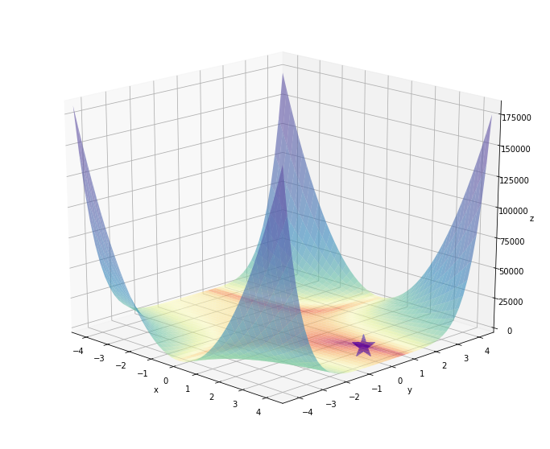

```python
fig = plt.figure(figsize=(12, 10))
ax = plt.axes(projection='3d', elev=20, azim=-45)

ax.plot_surface(x_mesh, y_mesh, z, norm=LogNorm(), rstride=1, cstride=1,
                edgecolor='none', alpha=.6, cmap=plt.cm.get_cmap("Spectral"))
ax.plot(*minima_, f(*minima_), 'b*', markersize=30)

ax.set_xlabel('x')
ax.set_ylabel('y')
ax.set_zlabel('z')

ax.set_xlim((x_min, x_max))
ax.set_ylim((y_min, y_max))

plt.show()
```

Contour plot with minima

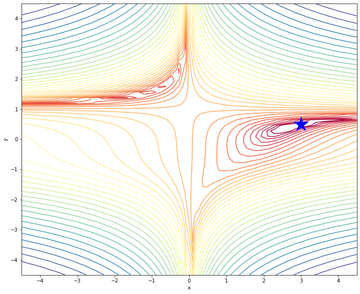

```python
fig, ax = plt.subplots(figsize=(12, 10))

ax.contour(x_mesh, y_mesh, z, levels=np.logspace(-.5, 5, 35), norm=LogNorm(), cmap=plt.cm.get_cmap("Spectral"))
ax.plot(*minima, 'b*', markersize=30)

ax.set_xlabel('x')
ax.set_ylabel('y')

ax.set_xlim((x_min, x_max))
ax.set_ylim((y_min, y_max))

plt.show()
```

Create a AdamOptimizer() class

```python
opt = AdamOptimizer(f, gradients, x_init=3.6, y_init=-1.15, learning_rate=0.1, beta1=0.9, beta2=0.999, epsilon=1e-8)
#opt = AdamOptimizer(f, gradients, x_init=None, y_init=None, learning_rate=0.1, beta1=0.9, beta2=0.999, epsilon=1e-8) # random initialize
```

```
x_init: 3.600
y_init: -1.150
```

```python
%time
opt.train(1000)
```

```
CPU times: user 0 ns, sys: 5 µs, total: 5 µs
Wall time: 8.34 µs
steps: 0  z: 92.176956  x: 3.60000  y: -1.15000
steps: 100  z: 0.112287  x: 2.43919  y: 0.29247  dx: -0.19310  dy: -0.75773
steps: 200  z: 0.021749  x: 2.69467  y: 0.40905  dx: -0.11603  dy: -0.16174
steps: 300  z: 0.004881  x: 2.84130  y: 0.45638  dx: -0.05005  dy: -0.06038
steps: 400  z: 0.001120  x: 2.92029  y: 0.47896  dx: -0.02270  dy: -0.02537
steps: 500  z: 0.000241  x: 2.96212  y: 0.49021  dx: -0.01022  dy: -0.01098
steps: 600  z: 0.000046  x: 2.98324  y: 0.49571  dx: -0.00440  dy: -0.00464
steps: 700  z: 0.000008  x: 2.99319  y: 0.49827  dx: -0.00177  dy: -0.00185
Enough convergence
steps: 722  z: 0.000005  x: 2.99448  y: 0.49860
```

Results

```python
print("Global minima")
print("x*: {:.2f}  y*: {:.2f}".format(minima[0], minima[1]))
print("Solution using the gradient descent")
print("x: {:.4f}  y: {:.4f}".format(opt.x, opt.y))
```

```
Global minima
x*: 3.00  y*: 0.50
Solution using the gradient descent
x: 2.9945  y: 0.4986
```

Beale function plot

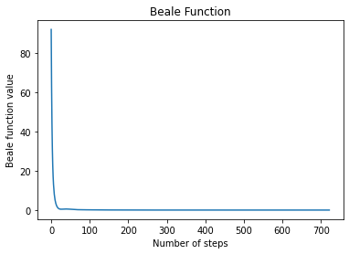

```python
#Plot the Beale function
plt.title('Beale Function')
plt.xlabel('Number of steps')
plt.ylabel('Beale function value')
plt.plot(opt.z_history)
plt.show()
```

Plot setting

```python
# putting together our points to plot in a 3D plot
number_of_points = 50
margin = 4.5
x_min = 0. - margin
x_max = 0. + margin
y_min = 0. - margin
y_max = 0. + margin
x_points = np.linspace(x_min, x_max, number_of_points)
y_points = np.linspace(y_min, y_max, number_of_points)
x_mesh, y_mesh = np.meshgrid(x_points, y_points)
z = np.array([f(xps, yps) for xps, yps in zip(x_mesh, y_mesh)])
```

3D plot with learning path

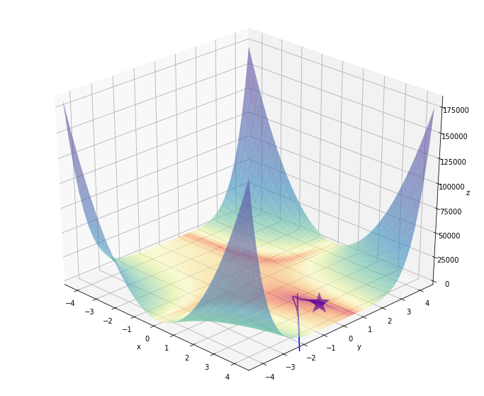

```python
path = opt.path

fig = plt.figure(figsize=(12, 10))
ax = plt.axes(projection='3d', elev=30, azim=-45)

ax.plot_surface(x_mesh, y_mesh, z, norm=LogNorm(), rstride=1, cstride=1,
                edgecolor='none', alpha=.6, cmap=plt.cm.get_cmap("Spectral"))
ax.plot(*minima_, f(*minima_), 'b*', markersize=30)
ax.quiver(path[0,:-1], path[1,:-1], opt.func([*path[::,:-1]]),
          path[0,1:]-path[0,:-1], path[1,1:]-path[1,:-1],
          opt.func([*path[::,1:]]) - opt.func([*path[::,:-1]]),
          color='b', length=1, normalize=False)

ax.set_xlabel('x')
ax.set_ylabel('y')
ax.set_zlabel('z')

ax.set_xlim((x_min, x_max))
ax.set_ylim((y_min, y_max))

plt.show()
```

Contour plot with learning path

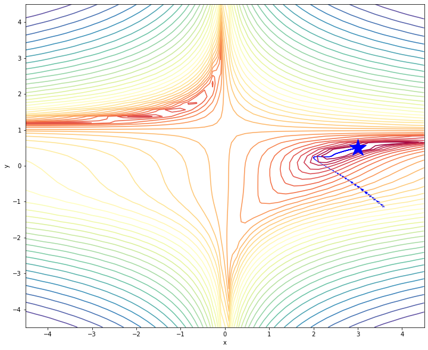

```python
fig, ax = plt.subplots(figsize=(12, 10))

ax.contour(x_mesh, y_mesh, z, levels=np.logspace(-.5, 5, 35), norm=LogNorm(), cmap=plt.cm.get_cmap("Spectral"))
ax.plot(*minima, 'b*', markersize=30)
ax.quiver(path[0,:-1], path[1,:-1], path[0,1:]-path[0,:-1], path[1,1:]-path[1,:-1],
          scale_units='xy', angles='xy', scale=1, color='b')

ax.set_xlabel('x')
ax.set_ylabel('y')

ax.set_xlim((x_min, x_max))
ax.set_ylim((y_min, y_max))

plt.show()
```

## *References:*

1. H. Robinds and S. Monro, “A stochastic approximation method,” Annals of Mathematical Statistics, vol. 22, pp. 400–407, 1951.
2. Sutton, R. S. (1986). Two problems with backpropagation and other steepest-descent learning procedures for networks. Proc. 8th Annual Conf. Cognitive Science Society.
3. Nesterov, Y. (1983). A method for unconstrained convex minimization problem with the rate of convergence o(1/k2). Doklady ANSSSR (translated as Soviet.Math.Docl.), vol. 269, pp. 543– 547.
4. Qian, N. (1999). On the momentum term in gradient descent learning algorithms. Neural Networks : The Official Journal of the International Neural Network Society, 12(1), 145–151. http://doi.org/10.1016/S0893-6080(98)00116-6
5. Bengio, Y., Boulanger-Lewandowski, N., & Pascanu, R. (2012). Advances in Optimizing Recurrent Networks. Retrieved from http://arxiv.org/abs/1212.0901
6. Sutskever, I. (2013). Training Recurrent neural Networks. PhD Thesis. http://www.cs.utoronto.ca/~ilya/pubs/ilya_sutskever_phd_thesis.pdf
7. Duchi, J., Hazan, E., & Singer, Y. (2011). Adaptive Subgradient Methods for Online Learning and Stochastic Optimization. Journal of Machine Learning Research, 12, 2121–2159. Retrieved from http://jmlr.org/papers/v12/duchi11a.html
8. Dean, J., Corrado, G. S., Monga, R., Chen, K., Devin, M., Le, Q. V, … Ng, A. Y. (2012). Large Scale Distributed Deep Networks. NIPS 2012: Neural Information Processing Systems, 1–11. http://papers.nips.cc/paper/4687-large-scale-distributed-deep-networks.pdf
9. CS231n Convolutional Neural Networks for Visual Recognition. https://cs231n.github.io/neural-networks-3/
10. Zeiler, M. D. (2012). ADADELTA: An Adaptive Learning Rate Method. Retrieved from http://arxiv.org/abs/1212.5701
11. Kingma, D. P., & Ba, J. L. (2015). Adam: a Method for Stochastic Optimization. International Conference on Learning Representations, 1–13.
12. Heusel, M., Ramsauer, H., Unterthiner, T., Nessler, B., & Hochreiter, S. (2017). GANs Trained by a Two Time-Scale Update Rule Converge to a Local Nash Equilibrium. In Advances in Neural Information Processing Systems 30 (NIPS 2017).
13. Dozat, T. (2016). Incorporating Nesterov Momentum into Adam. ICLR Workshop, (1), 2013–2016.
14. Johnson, M., Schuster, M., Le, Q. V, Krikun, M., Wu, Y., Chen, Z., … Dean, J. (2016). Google’s Multilingual Neural Machine Translation System: Enabling Zero-Shot Translation. arXiv Preprint arXiv:1611.0455.
15. Reddi, Sashank J., Kale, Satyen, & Kumar, Sanjiv. On the Convergence of Adam and Beyond. Proceedings of ICLR 2018.
16. Zhuang, J., Tang, T., Tatikonda, S., Dvornek, N., Ding, Y., Papademetris, X. and Duncan, J.S., 2020. Adabelief optimizer: Adapting stepsizes by the belief in observed gradients. arXiv preprint arXiv:2010.07468. https://arxiv.org/abs/2010.07468
17. Schmidt, R.M., Schneider, F. and Hennig, P., 2020. Descending through a Crowded Valley--Benchmarking Deep Learning Optimizers. arXiv preprint arXiv:2007.01547. https://arxiv.org/abs/2007.01547
18. Hansen, C., Optimizers Explained - Adam, Momentum and Stochastic Gradient Descent, https://mlfromscratch.com/optimizers-explained/#/
19. Buduma, N. and Locascio, N., 2017. Fundamentals of deep learning: Designing next-generation machine intelligence algorithms. " O'Reilly Media, Inc.".
20. Ruder, S., 2016. An overview of gradient descent optimization algorithms. arXiv preprint arXiv:1609.04747. https://ruder.io/optimizing-gradient-descent/
21. Why momentum really works, https://distill.pub/2017/momentum/
22. Odom, F., Understanding the New AdaBelief Optimizer, https://medium.com/the-dl/understanding-the-new-adabelief-optimizer-2db70ef6de1e